# mtk: A General-Purpose and Extensible R Environment for Uncertainty and Sensitivity Analyses of Numerical Experiments

Juhui Wang

MaIAGE, UR1404 – INRA, Domain de Vilvert

Robert Faivre

MIAT, UR875 – INRA, Auzeville

Hervé Richard

BioSp – INRA, Domaine Saint-Paul

Hervé Monod

MaIAGE, UR1404 – INRA, Domain de Vilvert

2015-10-01

Abstract

Along with increased complexity of the models used for scientific activities and engineering come diverse and greater uncertainties. Today, effectively quantifying the uncertainties contained in a model appears to be more important than ever. Scientific fellows know how serious it is to calibrate their model in a robust way, and decision-makers describe how critical it is to keep the best effort to reduce the uncertainties about the model. Effectively accessing the uncertainties about the model requires mastering all the tasks involved in the numerical experiments, from optimizing the experimental design to managing the very time consuming aspect of model simulation and choosing the adequate indicators and analysis methods.  
In this paper, we present an open framework for organizing the complexity associated with numerical model simulation and analyses. Named *mtk* (Mexico Toolkit), the developed system aims at providing practitioners from different disciplines with a systematic and easy way to compare and to find the best method to effectively uncover and quantify the uncertainties contained in the model and further to evaluate their impact on the performance of the model. Such requirements imply that the system must be generic, universal, homogeneous, and extensible. This paper discusses such an implementation using the R scientific computing platform and demonstrates its functionalities with examples from agricultural modeling.  
The package *mtk* is of general purpose and easy to extend. Numerous methods are already available in the actual release version, including Fast, Sobol, Morris, Basic Monte-Carlo, Regression, LHS (Latin Hypercube Sampling), PLMM (Polynomial Linear metamodel). Most of them are compiled from available R packages with extension tools delivered by package *mtk*.

# Introduction

Nowadays, computational modeling has become a common practice for scientific experiments and discoveries. Global climate models have been used for both short-term weather forecast (Lynch 2008) and long-term climate change (Risbey et al. 2014). Environmental models have been developed for assessing the impact of a waste water treatment plant on a river flow (Brock, Caupp, and Runke 1992). Epidemic models have been elaborated to investigate the mechanism by which diseases spread and to evaluate strategies to control their outbreaks (Papaix et al. 2014), etc. Most of them become more and more complex, with many parameters, state-variables and non-linear relationships, etc. Overloading the model to better mimic observed real data does not seem to be a passing practice but a continuing trend. Along with increased complexity of the models come diverse and greater uncertainties. Although computational modeling may improve our understanding of how an evidence emerges, and helps to get insight into how the elements of the system come together and interplay, one is usually left with the feeling that another model might produce different results and that some uncertainties have still remained somewhere in the system. *“Under the best circumstances, such models have many degrees of freedom and, with judicious fiddling, can be made to produce virtually any desired behavior, often with both plausible structure and parameter values”* (Hornberger and Spear 1981). Although we admit that such a statement is exaggerating, it is greatly necessary to look into this issue and to try our best effort to get insight into the sources of such doubts.

Uncertainty and sensitivity analyses, when correctly applied, may help to gain an understanding of the impact of the various sources of uncertainties and to further assess the system performance and set up strategies for getting better control over the behavior of the model (Helton et al. 2006; Cariboni et al. 2007; Marino et al. 2008). Numerous methods and software have been developed (Adams et al. 2013; Saltelli et al. 2005; Pujol, Iooss, and Janon 2014). Most of them are context-specific, domain-specific or theory-oriented. For example, Dakota was developed in the context of mechanics and large-scale engineering simulation (Adams et al. 2013). It is a closed complete software package which provides an efficient implementation of the iterative analysis model for parameter estimation, cost-based optimization, and sensitivity analysis. Implemented as a C++ library, methods developed in the project Dakota were widely used in a variety of large scale engineering projects relative to chemical (Salinger et al. 2004) and mechanical industries (Weirs, J. R. Kamm, L. P. Swiler, S. Tarantola, M. Ratto, B. M. Adams, W. J. Rider, and M. S. Eldred 2012). SimLab, on the other side, is a representative theory-oriented package which covers the global sensitivity analysis techniques derived from Monte Carlo analysis (Saltelli et al. 2005; Joint Research Centre 2006). Methods developed from SimLab are widely used in a large number of fields (Ciuffo et al. 2012). Although the software package offers a module to link for external model simulation and allows complex models beyond mathematical functions to be executed, such flexibility seems limited merely to the model implementation. The package obviously suffers from the lack of generality in the sense that it is difficult to include new methods especially those not based on Monte Carlo analysis. More ambitious, OpenTURNS (Baudin et al. 2015) builds on the global methodology promoted by an ESREDA group (Rocquigny, Devictor, and Tarantola 2008). It provides a great number of features for quantifying, prioritizing, and propagating uncertainties in computational models, but its extension requires programming skills that theoreticians and domain experts might not possess. More flexible and generic, Promethee provides a grid computing environment for numerical engineering and an interface for integrating R packages (Richet et al. 2009, 2010). When it comes to the software packages available for the R computing environment, there exists a great number of packages (Pujol, Iooss, and Janon 2014; Dupuy, Helbert, and Franco 2015; Monod, Bouvier, and Kobilinsky 2015; Lamboni, Monod, and Bidot 2015). We do not aim at providing an exhaustive review of all the packages here, but we we would like to point out package [*sensitivity*](https://CRAN.R-project.org/package=sensitivity) (Pujol, Iooss, and Janon 2014) which implements both the sampling and global analysis methods such as Sobol, FAST and Morris (Saltelli et al. 2005), package [*spartan*](https://CRAN.R-project.org/package=spartan) (M. A. T. Alden Kieran AND Read 2013; K. Alden et al. 2015) which compiles four widely used techniques for numerical experiments (the consistency analysis (Read et al. 2012), the robustness analysis (Read et al. 2012), the latin-hypercube sampling technique (Saltelli, Chan, and Scott 2000) and the eFAST technique (Marino et al. 2008)) and demonstrates their effectiveness for biological systems, and packages [*diceDesign*](https://CRAN.R-project.org/package=diceDesign) (Dupuy, Helbert, and Franco 2015) and [*planor*](https://CRAN.R-project.org/package=planor) (Monod, Bouvier, and Kobilinsky 2015) which implement the space-filling sampling technique (Pronzato and Müller 2012) and the techniques for regular factorial designs (Monod, Bouvier, and Kobilinsky 2015), respectively.

Although these tools are very useful and greatly contribute to the development and the popularity of uncertainty and sensitivity analyses, they present some drawbacks. Most of them offer no possibility to evolve or to integrate methods developed in other contexts. However, uncertainty and sensitivity analyses are intrinsically trial-and-error processes because of the lack of reliable knowledge and data about the causes of the uncertainties contained in the model. There is no method which is universal and suitable for all contexts. Practitioners must repeat, undertake numerous tests, and vary the parameters and methods until finding the best one fitting to the situation. Sticking to a method which is inappropriate for the circumstances leads inevitably to a wrong way and to misinterpret the results. Thus, it is necessary to develop a simple to use, but powerful software package allowing practitioners to test and compare different methods for their own data. Such an application needs to be easy to set up, and yet unifying in its ability to include a wide range of methods and powerful to objectively analyze and rapidly report the results.

Inspired from these issues, we tried to compile the available methods into a general purpose open platform and make them become accessible to researchers and practitioners from different disciplines. Named [*mtk*](https://CRAN.R-project.org/package=mtk) (Mexico Toolkit), the package we present here builds on an object-oriented framework using the R scientific computing platform. It provides facilities to interplay with external simulation platforms and to share data and knowledge with external applications in a seamless manner. It is easy to use, homogeneous, and offers a unique syntax and semantics for computing and data management. It is extensible in the sense that it tries to cover a large variety of *factor* types, and can easily integrate methods developed in the future without any major effort of reprogramming, even those developed by researchers not involved in the *mtk* initiative. It is self-contained and provides efficient tools to control all the processing tasks involved in the numerical experiments, from experimental design and model simulation to sensitivity computing and data reporting. Moreover, it is scalable to small or big projects, suitable for collaborative work in which the domain experts build the model and run the simulation, and the statisticians take charge of the different tasks of analyses and reporting.

We must note here that although the *mtk* package is designed to study any type of numerical simulation, one should not apply any method to any model on any occasion. How to match the methods to the problems is a difficult issue, which should not be accounted for only by software engineering but also by advice from domain experts and specialists on model exploration.

# Methodology

Based on the computation of specific quantitative measures that allow, in particular, assessment of variability in output variables and importance of input variables, both uncertainty and sensitivity analyses are relevant methods for exploring numerical experiments (Saltelli et al. 2005; Faivre 2013). Nevertheless, uncertainty and sensitivity analyses meet with different issues. Uncertainty analysis seeks to asses the impacts of the uncertainties contained in the inputs of the model on the outputs. It deals with the question of what level of uncertainty might be induced by the uncertainties contained in the inputs, and focuses on describing the probability distribution of the outputs as a function of the uncertainties contained in the inputs. In the simplest case, this probability distribution might be computed analytically from the characteristics of the uncertainties contained in the inputs. But in practice, the models are usually too complex to allow for any analytical solutions, and modern statistical methods must be used to estimate or approximate the probability distribution of the outputs. Various methods are already available. Among them, simulation methods seem to be the most representative and universal.

On the other hand, sensitivity analysis aims to identify the sources of the uncertainties and quantify their relative contributions. It deals with the question of which inputs exhibit the most important uncertain behaviors against the model, and allows us to focus on the ones that matter and ignore those that are less significant. Sensitivity analysis can be used to meet various objectives and goals such as identifying and prioritizing the most influential inputs, identifying non-influential inputs in order to fix them to nominal values, mapping the output behavior as a function of the inputs by focusing on a specific domain of inputs if necessary, calibrating model inputs using available information, etc. Terms such as influence, importance, ranking by importance, and dominance are all related to sensitivity analysis.

Sensitivity and uncertainty analyses rely on large and heterogeneous collection of approaches and tools. In this study, we try to find a consistent framework to unify the different approaches and tools. Our framework is a workflow-based one, which consists in decomposing the procedures of the uncertainty and sensitivity analyses into a series of elementary and generic tasks that can be manipulated and presented in a standard and homogeneous way. Each activity involved in the uncertainty and sensitivity analyses can be considered either as an elementary task or a combination of the elementary tasks. Appropriate combination and scheduling of the tasks allow to handle situations of any complexity. This workflow-based approach results in a unified way to cope with the heterogeneity of the activities involved in uncertainty and sensitivity analyses, and leads to a generic and extensible design.

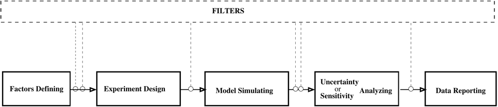

Figure 1: By decomposing the activities involved in uncertainty and sensitivity analyses into elementary tasks and using filters to connect them, we can cope with the heterogeneity of the approaches used in uncertainty and sensitivity analyses and unify them within a consistent and easily extensible framework.

The resulting workflow builds on five main tasks: i) choosing the input factors and their distribution uncertainties; ii) building the experimental design by factor sampling; iii) managing the model simulation; iv) analyzing the results obtained from the simulation; v) preparing to present and report the results. Thus, all approaches can be considered as a partial or complete combination of the main tasks. Moreover, filters are available and can be added to cope with atypical and complex situations. They are often used to convert or import data in order to connect the main tasks.

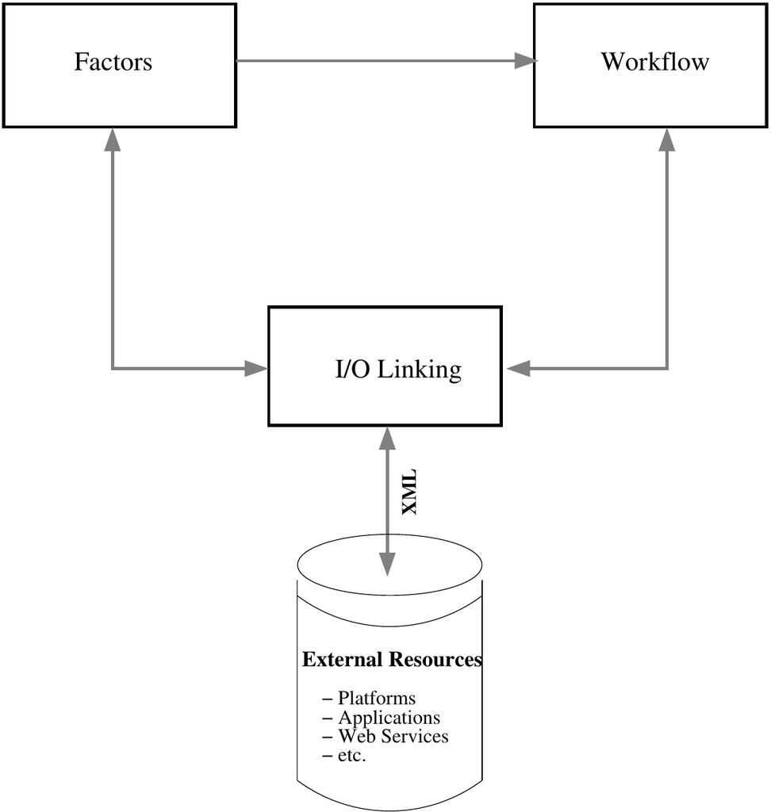

Figure 2: A general view of the system. The system is mainly composed of three components: a unit to manage the *factors* and their uncertainties, a unit to manage the processes and workflow, and a unit to manage the collaboration with external resources.

Table 1: The principal classes used in the *mtk* package to manage the *factors* and the processes involved in numerical experiments.

| Classes | Definition | Nature |
| --- | --- | --- |
| ‘`mtkFactor`’ | Entity used to represent a *factor* | Instantiable |
| ‘`mtkExpFactors`’ | Entity used to collect all the *factors* involved | Instantiable |
|  | in the experiment |  |
| ‘`mtkDomain`’ | Entity used to define the uncertain domain | Instantiable |
|  | of a *factor* |  |
| ‘`mtkLevels`’ | Entity used to define a discrete probability | Instantiable |
|  | distribution |  |
| ‘`mtkValue`’ | Triplet used to define a typed variable | Virtual |
| ‘`mtkParameter`’ | Entity used to define a parameter | Instantiable |
| ‘`mtkFeature`’ | Entity used to represent complex | Instantiable |
|  | relationships among *factors* |  |
| ‘`mtkProcess`’ | Entity used to manage a process | Virtual |
| ‘`mtkExpWorkflow`’ | Entity used to manage the workflow | Instantiable |
| ‘`mtkExperiment`’ | Entity to manage a simplfied version of | Instantiable |
|  | workflow |  |
| ‘`mtkParsor`’ | Entity used to parse XML files | Instantiable |
| ‘`mtkReporter`’ | Entity responsible for advanced data reporting | Virtual |
| ‘`mtkResults`’ | Entity used to hold results produced by a | Virtual |
|  | process |  |
| ‘`mtkDesigner`’ | Entity used to manage *design* process | Instantiable |
| ‘`mtkSystemDesigner`’ | Entity used to manage *design* method | Instantiable |
|  | implemented as a system application |  |
| ‘`mtkNativeDesigner`’ | Entity used to manage methods *design* | Instantiable |
|  | implemented as an R function |  |
| ‘`mtkMorrisDesigner`’ | Entity used to manage the process | Instantiable |
|  | implementing the method Morris |  |

# Architecture and design

Building on an object-oriented framework, the *mtk* package follows the recommendation for S4 classes and methods available in R (Chambers 2008). As shown in Figure 2, it comprises three mandatory components: the factor unit, the workflow unit, and the data import and export unit. Each unit is part of a service mission and manages the exchange of data and services with other units via interfaces. Thus, a unit knows other units and communicates with them only through the interfaces. This practice promotes efficient software engineering when multiple teams are involved, and makes the long-term software maintenance easier (Chambers 2014).

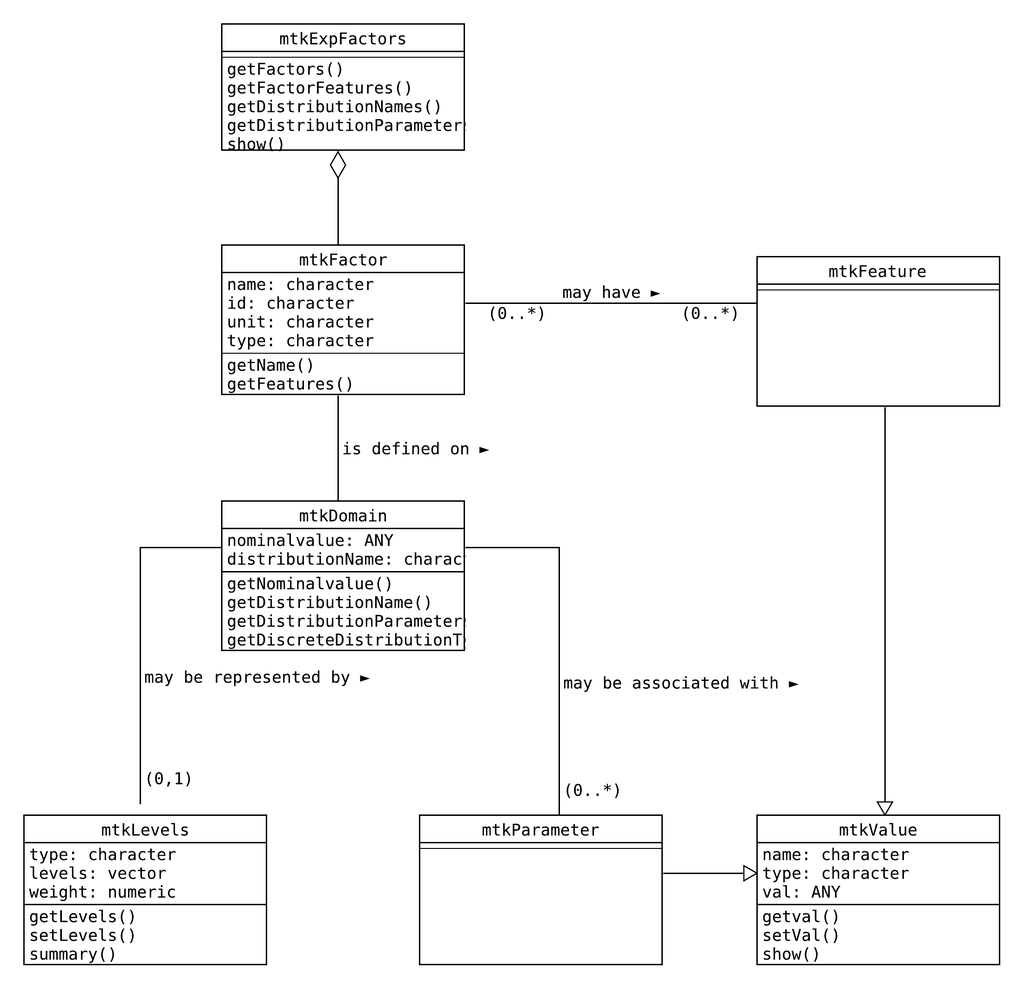

Figure 3: Data model used to manage the *factors* and their uncertainties. The model is represented using the UML notation (Fowler 2003), and the referred classes are presented in Table 1.

## The factor unit

The factor unit manages data and services with regard to the parameters and inputs of the model. It also ensures efficient support to manage the uncertainty behaviors that we know about the model. When running an uncertainty or sensitivity analysis, the first thing to do is to determine what the parameters and inputs to the model are and, among them, which parameters and inputs exhibit uncertainties. Such kinds of parameters and inputs are referred to as *factors*. Since the uncertainty of the *factor* is restricted within a domain, we usually set it up with a probability distribution function. The factor unit is the component which is responsible for managing the information about the *factors* and their uncertainty domains such as the arguments to the probability distribution function, whether the *factors* are correlated and how they correlate, and so on. An important feature of the *mtk* package is its capability to manage *factors* with complex characteristics. They might be qualitative or quantitative as well as continuous or discrete.

Table 1 defines the classes used in the *mtk* package to manage the *factors* and their uncertainties, and Figure 3 shows the data model in UML notation (Fowler 2003). It provides a consistent framework for both representing and handling information useful for describing the *factors* and their uncertainty domains precisely. We have focused on describing the relevant data and their relationships and sought to give a consistent data framework which can be considered as general as possible and easily extensible to integrate new methods developed in the future even by researchers not involved in the *mtk* initiative (for more discussion, please refer to Section 4.1).

## The workflow unit

This component manages and orchestrates the execution and progress of the processes involved in the numerical experiments. In this task, a process takes much more than calling a more or less sophisticated function within the software package. This is able to analyze information from the context, to define a strategy taking into account the availability of data and services (which might be local or remote, and if locally available, might be implemented as an independent system application, an R function, or an internal element of the *mtk* package), and finally to select the appropriate processing to launch, to formulate the produced results, and to make them available to other components of the system or independent applications outside the system.

In the current version, the *mtk* package supports four types of processes: the parser for XML files, the experimental design, the model simulation, and the computation of sensitivity indices. Each process possesses descriptors to inform about its state and progress: whether the process is ready to run or it is running or it has already run and produced the results that we expected. The workflow manager has the control over the launching and evolution of all the processes involved. Before invoking a process, the workflow manager makes sure that all required resources are available and that they are coherent with the state of the process. After the execution of a process, it checks the consistency of the results and makes them available for other processes.

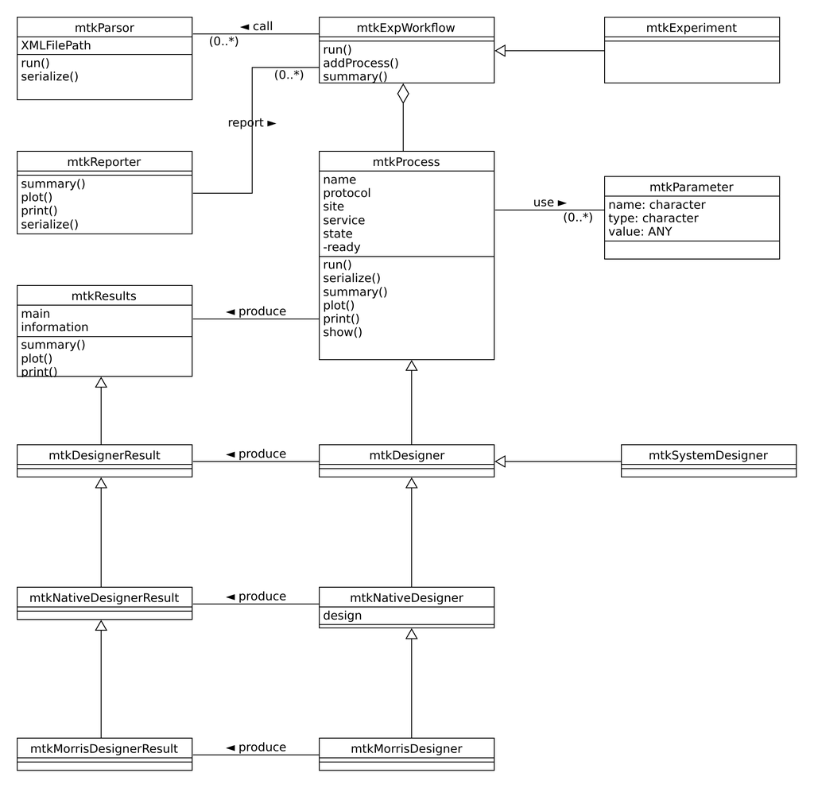

Figure 4: UML data model for organizing the processes and workflow implemented in the *mtk* package. The referred classes are presented in Table 1. To make the schema readable, only the elements related to the Morris method for experimental design are shown. The prefix `Native` is used to refer to the process implemented as an R function, and the prefix `System` is used when the process is implemented as an independent system application.

As shown in Table 1 and Figure 4, processes are organized into a hierarchical structure by inheritance. The common components of the processes are summarized within an abstract class named ‘`mtkProcess`’. The child classes inherit the components from their parent classes higher in the hierarchical structure. For example, ‘`mtkDesigner`’ is a process which inherits the common components defined within the ‘`mtkProcess`’ and adds new features specific to the experimental design. The process ‘`mtkMorrisDesigner`’ shares common components with other methods from experimental design and further appends new features specific to the Morris method (Saltelli et al. 2005). From Figure 4, we can also note that each process is associated with a specific class for managing the results produced by the process. In fact, results produced by methods from uncertainty and sensitivity analyses are very different both in terms of contents and in terms of structures. Some methods produce data which could be represented within a data frame, and some others produce results that can be formulated only in the format of a list. Classic approaches require that we must always be concerned with the structure used to hold the data, and develop bespoke functions for each type of the results (Chambers 2014). The object-oriented approach allows us to be released from such constraints. The classes that hold the data are not only responsible for data storage but also for the services to transform and report the data. For example, the experimental design is no longer treated only as a function to produce data in some specific format, but considered as a process which is an active element not only capable of generating and reporting the data but also capable of checking their consistency and setting up relationships with other components of the system.

## The data import and export unit

Based on widely used open standards such as XML, URI (Uniform Resource Identifier), Web services, etc., the data import and export unit allows elements of the package to communicate and to be extended with external resources such as independent platforms or applications for model simulation, Web services that supply data or methods for experimental design and sensitivity analysis, etc. For instance, the workflow for a sensitivity analysis might be generated from independent external platforms and coded into an XML file; the *mtk* package can import the XML file, set up the workflow, and run it automatically. This can be referred to as one of the methods that the *mtk* package uses to integrate external platforms as a collaborative component.

The package also provides serializing functions allowing to save the internal status of the workflow into an XML file so that independent external applications could collect information about the processes and data involved in the workflow, and further wrap them as an internal component (see Section 6).

# Features and functions

## Representing the *factors* and their uncertainties in an homogeneous and extensible way

In the *mtk* package, we sought to provide a consistent and easily extensible framework for both representing and handling information useful for describing the *factors* and their uncertainty domains precisely. For example, the concept *feature* was introduced to address the issue about the diversity of the *factors* in their types and relationships. Mathematically speaking, a *feature* is a simple triplet that can be used to make come together a variable name, a data type and a numerical value. The *feature* concept is simple but fundamental to both the scalability of the implemented methods and the extensibility of the package. In fact, *factors* used in uncertainty and sensitivity analyses may have different formats and be defined on various domains. In addition, they may be qualitative or quantitative, continuous or discrete, ordered or unordered, etc. Furthermore, several *factors* may be linked by constraints in space or time, and they may be either correlated or hierarchical as well. Therefore, we need a unified framework to cope with such a variety of *factors*. The concept of a *feature* has accomplished this goal. It allows to set up a universal framework for depicting the *factors* and their relationships and leads to a consistent and unified schema to manage the heterogeneity of the *factors*: an ordered list of *features* associated with a *factor* can be used to describe the spatial and temporal location of a *factor*, and one or more *features* can be applied to a group of *factors* to catch the relationship of any complexity among them, etc.

The *factors* and their uncertainties are represented with the class ‘`mtkFactor`’. This class has four primary attributes and two associative attributes:

**name**

The name of the *factor* used in the workflow.

**id**

The name of the *factor* used in the simulation model if it is different.

**type**

The type of the values associated with the *factor*.

**unit**

A unit of measurement associated with the values of the *factor* if it exists.

**domain**

An object of the class ‘`mtkDomain`’ to describe the uncertainty of the *factor*.

**featureList**

A list of objects from the class ‘`mtkFeature`’ to provide additional information about the underlying *factor* such as spatial or temporal location, relationships among a group of *factors*, etc.

The attributes `name`, `id`, `type` and `unit` are simple strings, and the associative attributes `domain` and `featureList` are objects of the classes ‘`mtkDomain`’ and ‘`mtkFeature`’ respectively.

There are two ways that can be used to define the *factors*: interactively within an R session or by parsing an XML file. The interactive definition of the *factors* within an R session is implemented with the function `make.mtkFactor()`, and the following examples demonstrate this function. The definition of the *factors* from an XML file might be considered as a component of the data import and export unit which will be discussed in the next section.

```r
# Load mtk package:
      library(mtk)
# Define a continuous factor:
      make.mtkFactor('A', distribName = 'unif', distribPara = list(min = 0, max = 1))
# Define a new discrete factor:
      make.mtkFactor('D', distribName = 'discrete',
            distribPara = list(type = 'categorical',
            levels = c('a', 'b', 'c'), weights = rep(1/3, 3)))
```

The first example shows how to define a *factor* named $A$, whose uncertainty is defined by a continuous uniform distribution over the interval $[0, 1]$. The second example demonstrates the definition of a categorical *factor* which is named $D$, and takes values from the set $\{a, b, c\}$ and each with a probability equal to $1/3$.

## Formalizing the data and services for collaborative work

The language XML has been used to overcome the heterogeneity of data and services exchanged between the *mtk* package and external resources. Indeed, one of the main difficulties that we met in building the *mtk* package was the variety of data and services that need to be managed in the context of uncertainty and sensitivity analyses. Data and services might be local or remote, and implemented in R or other programming languages. They might also have different structures and various formats. Instead of putting emphasis on the data and services themselves, we have chosen to focus on the structure of the data and services that the package exchanges with external resources, and to formalize them according to the XML standards. XML schemas were elaborated and used to tackle the issue of numerical experiments in the open collaborative framework (Richard et al. 2013). By reformalizing the elements involved in the experimental design, the model simulation control, the workflow management and the data reuse, the XML schemas lead to a unified representation of the data and services that an open collaborative framework needs to produce or consume. Thus, managing the heterogeneity of data and services involved in the uncertainty and sensitivity analyses is greatly simplified and highly standardized. From the point of view of programming, it is reduced to the development of a class which is able to parse the XML files following the defined XML schemas.

The XML parsing has been realized with the class ‘`mtkParsor`’, and its use is very simple. We just need to specify the path to access the XML file and the workflow into which the extracted information will be directed. The following code shows how to construct a parser from an XML file, which is delivered with the distribution package. Note that the XML file is usually produced by an external platform, and thus the XML parsing mechanism can also be used as a way to integrate the *mtk* package with external applications.

```r
# Create a parser to parse the XML file : './WWDM.xml'.
# Note that the XML file is delivered within the package "mtk"
     parser <- mtkParsor('./WWDM.xml')
```

## Organizing the implementation of the methods hierarchically and presenting them with a unified syntax

To collect all the available methods into a unique framework and to present them under a unified syntax, we adopted a workflow-based approach which consists in decomposing the procedures of sensitivity analysis into a series of elementary and generic processes, and organizing them into a hierarchical structure. Each activity involved in sensitivity analysis can be considered either as an elementary process or a combination of elementary processes. Appropriate combination of the processes allows the handling of situations of any complexity.

Taking the experimental design as an example, this is part of the mission services provided by the workflow management unit. The *mtk* package offers a generic and easily extensible implementation of a Web-based open framework, and such an implementation needs to be carefully thought and designed. In fact, the methods used to generate the experimental design might be complex and complicated. Besides the inherent variety of the contexts where the methods were developed, they might be implemented locally or remotely and in different programming languages and according to various protocols. Furthermore, the experimental design might be generated on-line or off-line. To provide the package with an architecture easy to extend and the ability to cope with different situations, a general purpose class ‘`mtkDesigner`’ is derived from the abstract class ‘`mtkProcess`’ so that users can extend the framework to fit to specific circumstances (please see the class organization presented in Figure 4). The ‘`mtkDesigner`’ class inherits the following slots from the class ‘`mtkProcess`’, which enable the Web-based computing:

**protocol**

The protocol used to run the process. It may take on values such as `"mtk"`, `"R"`, `"system"` and `"http"`, where the value `"mtk"` indicates that the process is implemented as an internal element of the *mtk* package, the value `"R"` that the process is implemented as a native R function, the value `"system"` that the process is implemented as an independent application, and the value `"http"` that the process is implemented with Web service technologies.

**site**

The site where the processing is implemented.

**service**

The name of service which realizes the underlying tasks.

To make importing methods implemented locally as an independent R function easier, a class ‘`mtkNativeDesigner`’ derived from ‘`mtkDesigner`’ is provided together with its constructor as follows:

```r
      mtkNativeDesigner(design = NULL, X = NULL, information = NULL)
```

This class can deal with two scenarios, whereby either the method of experimental design is implemented as an independent function in R or the experimental design was generated off-line. The first example below shows how to construct an experimental design from a method implemented as an independent R function, and the second shows how to import an experimental design generated off-line.

```r
# Set up an experimental design with a method implemented
# by an R function named 'mc04()'
      sampler <- mtkNativeDesigner(design = mc04(factors,
                    distribution, parameters, size = 20))
# Set up an experimental design by importing the design produced
# off-line which is stored as a data.frame named 'plan'.
      sampler <- mtkNativeDesigner(X = plan,
                    information = list(method = 'Morris', size = 20))
```

Note that the technical details mentioned before are just intended for importing in live external elements into package *mtk*. When it comes to the elements already integrated in the package, one does not need to care about how the methods are physically implemented (locally or remotely, as an R function or through a Web service, etc. ). To use a method, it is only necessary to instantiate an object from the underlying class. For instance, to set up an experimental design with the method Morris wherever it is implemented physically, we just need to instantiate an object of the class ‘`mtkMorrisDesigner`’.

```r
# Set up an experimental design with the method 'Morris' with parameters.
      sampler <- mtkMorrisDesigner(listParameters = list(size = 20))
```

Currently, the *mtk* package supports three kinds of elementary processes: *designer*, *evaluator* and *analyser*. Each manages one of the principal activities involved in uncertainty and sensitivity analyses, and is associated respectively with the experimental design, the model simulation and the sensitivity computing.

We should point out again that within the *mtk* package, all processes involved in the sensitivity analysis are managed in the same way just as the designer is managed. For instance, the common properties involved in the model simulation are put into the class ‘`mtkEvaluator`’ which is itself derived from the class ‘`mtkProcess`’. Also, the models might be implemented locally or remotely, written in R or in another programming language, and the simulation might be produced on-line or off-line. If the model is implemented locally, the specific class proposed is the class ‘`mtkNativeEvaluator`’ with the associated constructor as follows:

```r
      mtkNativeEvaluator(model = NULL, Y = NULL, information = NULL)
```

This class has the same syntax as the class ‘`mtkNativeDesigner`’, and this is one of the biggest advantages of using the *mtk* package. It provides a homogeneous way and mechanism to manipulate all the methods and functions managed by the package. For example, if we want to simulate the Ishigami model (Ishigami and Homma 1990) which describes the dynamics of a non-linear function with three *factors*, it does not take more than to set up a model evaluator (or simulator) with the code as follows:

```r
# Simulate the 'Ishigami' model which has no parameter.
      simulator <- mtkIshigamiEvaluator()
```

As well, to use the Morris method to compute the sensitivity indices is not harder than to write the following code:

```r
# Set up a process to compute the sensitivity indices with the Morris method
      analyzer <- mtkMorrisAnalyser(listParameters = list(nboot = 20))
```

## Managing efficiently the activities with a workflow-based approach

A workflow is an orchestrated and repeatable sequence of activities that are responsible to transform data and to provide services. The *mtk* package organizes the activities into standardized and elementary processes. Before invoking a process, the workflow ensures that the process is ready to run and the needed data are available and consistent with the state of the process. After running the process, the workflow manages the results, makes them available, and ensures that they can be successfully reused. Indeed, some processes are very time-consuming, and they require enormous computing power to produce results. This is especially true for complex model simulations which may take days or even weeks on a cluster before making the simulated data available. Therefore, it is important to avoid restarting a process if no new data has been produced even if the workflow needs to be restarted to incorporate new elements. For instance, suppose that an experiment was designed with the Monte Carlo method and analyzed with the multiple regression method, and one wishes to analyze the same simulated data with another method. In this case, it would be possible to reuse the experimental design and the simulated data already obtained. The workflow implemented in the *mtk* package manages these kinds of constraints and enables to maximize the reuse of resources. An example of this approach will be presented in Section 5.

The workflow management has been implemented with the class ‘`mtkExpWorkflow`’, which can be created in two ways: either interactively within an R session or automatically through an XML file.

The interactive method is the most common procedure used by R users, and it consists of four steps: i) defining the *factors* and their uncertainties; ii) specifying the processes involved in the sensitivity analysis; iii) forming a workflow; and iv) running the workflow and reporting the results. The example below presents the construction and execution of a workflow to analyze the Ishigami model with the Basic Monte Carlo method for the experimental design and the regression method for sensitivity computing.

```r
# Load the mtk package:
      library(mtk)
# Specify the factors and their uncertainty domains:
      x1 <- make.mtkFactor(name = 'x1', distribName = 'unif',
                    distribPara = list(min = -pi, max = pi))
      x2 <- make.mtkFactor(name = 'x2', distribName = 'unif',
                    distribPara = list(min = -pi, max = pi))
      x3 <- make.mtkFactor(name = 'x3', distribName = 'unif',
                    distribPara = list(min = -pi, max = pi))
      ishi.factors <- mtkExpFactors(list(x1, x2, x3))
# Specify  the processes involved:
      designer <- mtkBasicMonteCarloDesigner(listParameters = list(size = 20))
      simulator <- mtkIshigamiEvaluator()
      analyser <- mtkRegressionAnalyser(listParameters = list(nboot = 20))
# Form the workflow:
      experiment <- mtkExpWorkflow(expFactors = ishi.factors,
                     processesVector = c(design = designer,
                     evaluate = simulator, analyze = analyser))
# Run the workflow and report the results:
      run(experiment)
      summary(experiment)
```

The automatic method consists of controlling the workflow through an XML file in which all the information necessary for the definition and execution of the workflow is specified. The XML files can be created manually by users or even more often by external platforms. The latter allows to manage the *mtk* workflow from an external platform and offers a way to carry out uncertainty and sensitivity analyses without having to get out of the modeling or simulation platform. Once the XML file is formed, the *mtk* package takes control over the XML file and provides facilities for information extraction, and workflow initialization and control.

The example below shows how to build a workflow from an XML file. Note that the XML file used here can be found in the supplementary material provided with the distributed package.

```r
# Load the mtk package:
      library(mtk)
# Create a workflow from the XML file:  './WWDM.xml'
      expXML <- mtkExpWorkflow(xmlFilePath = './WWDM.xml')
# Run the workflow and report the results
      run(expXML)
      summary(expXML)
```

## Extending the package with new or existing methods

In order to encourage researchers to publish their methods through the *mtk* framework, we provide facilities to easily import available methods directly into the system. The *mtk* package comes with three tools: `mtk.designerAddons()`, `mtk.evaluatorAddons()`, and `mtk.analyserAddons()`.

The tool `mtk.designerAddons()` is a function that allows users to turn new or existing methods for experimental designs developed as R functions into classes compliant with the *mtk* package.

This function has the following prototype:

```r
      mtk.designerAddons(where, library, authors, name, main, summary = NULL,
          print = NULL, plot = NULL)
```

**where**

`NULL` or a string to denote the file containing the R function to convert.

**library**

`NULL` or a string to denote the name of a package containing the R function to convert if it is provided via a package.

**authors**

`NULL` or the copyright information about the authors of the R function.

**name**

A string to name the method when used with the *mtk* package.

**main**

The name of the R function implementing the method.

**summary**

`NULL` or a special version of the `summary` method provided in the file *where* or in the package *library*.

**plot**

`NULL` or a special version of the `plot` method provided in the file *where* or in the package *library*.

**print**

`NULL` or a special version of the `print` method provided in the file *where* or in the package *library*.

No constraints are imposed on the function to convert except for the format of its inputs and outputs. The R function implementing the method must have at least the three arguments: `factors`, `distribNames`, and `distribParameters`. The argument `factors` takes as values either a number or a list of names for enumerating the *factors* to analyze. The arguments `distribNames` and `distribParameters` are both lists, whose elements are used to specify the uncertainty domains of the *factors*.

The output produced by the function must be formatted as a named list with two elements: `main` and `information`. The element `main` is a `data.frame` containing the produced experimental design and the element `information` is a named list whose elements are used to provide optional information about the method used.

If the `summary()`, `print()` and `plot()` methods provided within the package *mtk* are not concise enough to describe the underlying experimental design, or the method developers wish to report it in a specific way, they can replace these methods by new ones.

The example below shows how to use the function `mtk.designerAddons()` to convert an existing method into *mtk* compliant classes so that the method can be seamlessly used with the package. In order to demonstrate the potential of the package, we have chosen to import an existing method implemented in an independent package: the method *"Morris"* of the package *sensitivity* (Pujol, Iooss, and Janon 2014). The file `morris_sampler.R` contains the program codes used to wrap the original function so that the inputs and outputs meet the requirement of the tool `mtk.designerAddons()`. In this example, the wrapped function is renamed `sampler.morris()`. In order to better outline the produced experimental design, a new method of the function `plot()` for ‘`morris`’ objects has been provided via the function `plot.morris()`.

```r
# Load the mtk package:
      library(mtk)
# Convert the file 'morris_sampler.R' to a mtk compliant class 'mtkMorrisDesigner':
      mtk.designerAddons(where = 'morris_sampler.R',
         authors = 'G. Pujol, B. Ioos, and A. Janon',
            name = 'Morris', main = 'sampler.morris', plot = 'plot.morris')
# Integrate the new class into the mtk package
      source('mtkMorrisDesigner.R')
```

Here, the `mtk.designerAddons()` tool generates a file named `mtkMorrisDesigner.R` which can be integrated directly into the *mtk* package via the R command `source()`.

The other two tools `mtk.evaluatorAddons()` and `mtk.analyserAddons()` operate in the same way as `mtk.designerAddons()` does. They can be used respectively to integrate simulation models and to integrate methods for computing the sensitivity indices. An example of using the tool `mtk.evaluatorAddons()` can be found in the next section.

# A case study

In this section, we present an example of a decision support model analyzed with the *mtk* package. The model used in (Munier-Jolain, Chauvel, and Gasquez 2002) is a dynamic model simulating the effect of weeds (meadow foxtail) on the yield of a crop of wheat as a function of different agricultural practices, including soil preparation, weeding and crop varieties. The flow is simulated at a yearly time step. Five state variables are used, and their dynamics are modeled with a system of non-linear first order difference equations.

Table 2: The state variables used in the Weed model and the initial values of the state variables characterizing the population of foxtail at $t=0$.

| *State Variable* | Definition | Initial Value |
| --- | --- | --- |
| $S$ | Number of seeds of foxtail by $m^2$ | 68 000 |
|  | found in the cultivated plot. |  |
| $d$ | Number of foxtail plants by $m^2$ | 400 |
|  | found at the beginning of the season. |  |
| $SSBa$ | Number of seeds of foxtail by $m^2$ | 3 350 |
|  | found on the surface of the soil |  |
|  | after tillage. |  |
| $DCSa$ | Number of seeds of foxtail by $m^2$ | 280 |
|  | found under the surface of the soil |  |
|  | after tillage. |  |
| $Y$ | Yield of wheat on the plot | — |
|  | (ton per $m^2$) |  |

The model builds both on input variables describing the agricultural practices and on parameters describing the effect of the agricultural practices on the state variables of the model. The input variables are supposed to be fixed, but some parameters are uncertain. We will use the *mtk* package: i) to analyze the effect of the uncertainty of the parameters on the wheat yield (the state variable $Y$), and ii) to determine the sensitivity of the state and output variable Y to the uncertainties contained in the different parameters.

The model takes into account three types of input: i) the initial values of the state variables characterizing the population of foxtail at $t = 0$ (see Table 2), ii) the year by year agricultural practices (tillage, weeding, cultivated crop varieties), and iii) $16$ parameters of the model (they are supposed to be fixed, but contain some uncertainties).

Agricultural practices applied each year to the crop are described with the help of three binary variables: `Soil`, `Herb`, and `Crop`. If the soil is tilled, we set $Soil=1$, otherwise $Soil=0$. Similarly, we set $Herb=1$ if herbicide is applied, $Herb=0$ otherwise , and $Crop=1$ if the cultivated plant is a variety of winter wheat, $Crop=0$ otherwise. In this paper, we explore a simplified model where only winter wheat is supposed to be cultivated ($Crop=1$) and the tillage is always realized every other year. Also, only two scenarios of the weeding treatment are explored: i) systematic treatment each year, and ii) systematic treatment except the third year.

Since the *factors* (parameters with uncertainty) are supposed to be fixed, their uncertainties can be represented with common probability distribution functions. Table 3 shows the domains of uncertainties associated with such parameters.

Table 3: The *factors* and their domains of uncertainties used in the Weed model. The domains of uncertainties are all modeled with a uniform probability distribution whose range is fixed from *Min Value* to *Max Value*.

| *Factors* | Definition | Min Value | Max Value |
| --- | --- | --- | --- |
| $mu$ | Annual decline rate | 0.76 | 0.92 |
| $v$ | Proportion of non aborted seeds | 0.54 | 0.66 |
| $phi$ | Loss of the fresh seeds | 0.50 | 0.61 |
| $beta.1$ | Proportion of the foxtail seeds | 0.86 | 1.05 |
|  | found under the surface after tillage |  |  |
| $beta.0$ | Proportion of the foxtail seeds | 0.18 | 0.22 |
|  | found under the surface without tillage |  |  |
| $chsi.1$ | Proportion of the foxtail seeds | 0.27 | 0.33 |
|  | found on the surface after tillage |  |  |
| $chsi.0$ | Proportion of the foxtail seeds | 0.045 | 0.055 |
|  | found on the surface without tillage |  |  |
| $delta.new$ | Germination rate for fresh seeds | 0.14 | 0.17 |
| $delta.old$ | Germination rate for old seeds | 0.27 | 0.33 |
| $mh$ | Efficiency of the herbicide | 0.88 | 1.08 |
| $mc$ | Mortality rate caused by cold weather | 0 | 1 |
| $Smax.1$ | Number of the seeds harvested | 400 | 490 |
|  | per plant (winter variety) |  |  |
| $Smax.0$ | Number of the seeds harvested | 266 | 326 |
|  | per plant (spring variety) |  |  |
| $Ymax$ | Potential yield $t/ha$ | 7.2 | 8.8 |
| $Rmax$ | Parameter used to calculate the loss | 0.0018 | 0.0022 |
| $Gamma$ | Another parameter used to | 0.0045 | 0.0055 |
|  | calculate the loss |  |  |

The computing code of the model is enclosed in the supplementary material provided with the package and in (Faivre et al. 2013). Note that to integrate the model into the *mtk* package, we do not need to reprogram the model, but just wrap the main function `WEED.simule()` in the file `WeedModel_v2.R`, say, so that its inputs and outputs conform with the requirement of the function `mtk.evaluatorAddons()` presented in Section 4.5.

Once the model is wrapped, we append it to the *mtk* package so that it can be seamlessly used with the *mtk* package.

```r
# Load the package mtk:
      library(mtk)
# Transform the model into a mtk compliant class:
      mtk.evaluatorAddons(where = 'WeedModel_v2.R',  authors = 'D.Makowski(2012)',
            name = 'Weed', main = 'WEED.simule')
# Load the mtk compliant class generated before into the mtk package:
      source('mtkWeedEvaluator.R')
```

## Uncertainty analysis

Recall that realizing a numerical experiment with the *mtk* package is composed of four steps: i) choose the *factors* and specify their uncertainties; ii) set up the processes involved in the numerical experiment; iii) form a workflow; and iv) run the workflow and report the results.

First, the uncertain domains associated with the *factors* are defined with function `make.mtkFactor()`. Sixteen *factors* are considered, and each is assumed to follow a uniform distribution whose range is fixed according to Table 3. The code below shows how we defined the uncertain domains of the *factors* within R.

```r
# "table3.data" is a file referring to the Table 3 defined in the text.
    table3 <- read.table("table3.data", header = TRUE)
    facteurs <- list()
    for(i in 1:16){
        facteur.i <- as.character(table3$Factors)[i]
        facteurs[facteur.i] <- make.mtkFactor(name = facteur.i,
            distribName = "unif",
                    distribPara = list(min = table3$MinValue[i],
                    max = table3$MaxValue[i]))
    }
    weedFactors <- mtkExpFactors(facteurs)
```

Here, the Basic Monte Carlo method is used for the experimental design, and $1 000$ samples are generated. The code below shows the underlying procedure:

```r
      plan <- mtkBasicMonteCarloDesigner(listParameters = list(size = 1000))
```

Two instantiations of the model are evaluated, and they correspond to the cases that weeding treatment is applied every year and that the weeding treatment is not applied only for the third year, respectively. Note that the agricultural practices are encapsulated into the argument `decision`: $decision=1$ represents the first scenario and $decision=2$ represents the second.

```r
      weed.case1 <- mtkWeedEvaluator(listParameters = list(decision = 1, outvar = 3))
      weed.case2 <- mtkWeedEvaluator(listParameters = list(decision = 2, outvar = 3))
```

Consequently, two workflows are built, and they will be used to manage the analyses of the two models defined above.

```r
      exp1 <- mtkExpWorkflow(expFactors = weedFactors,
             processesVector = c(design = plan, evaluate = weed.case1))
      exp2 <- mtkExpWorkflow(expFactors = weedFactors,
             processesVector = c(design = plan, evaluate = weed.case2))

      set.seed(2) # to fix the seed of the random generator for exp1
      run(exp1)
      set.seed(2) # to fix the seed of the random generator for exp2
      run(exp2)
```

Sometimes, users may choose not to use the reporting tools provided with the *mtk* package to present their results. The function `extractData()` allows them to fetch the data managed by the *mtk* package as independent data structures supported by the R computing platform and to manipulate them freely. Hereinafter, the simulated results ($1000$ simulations per year for $10$ years) are stored in two variables: $Y_1$ and $Y_2$. Notice that we are only interested in the yields of the third year ($outvar=3$) since they are the only data which can reflect the effect of weeding treatment.

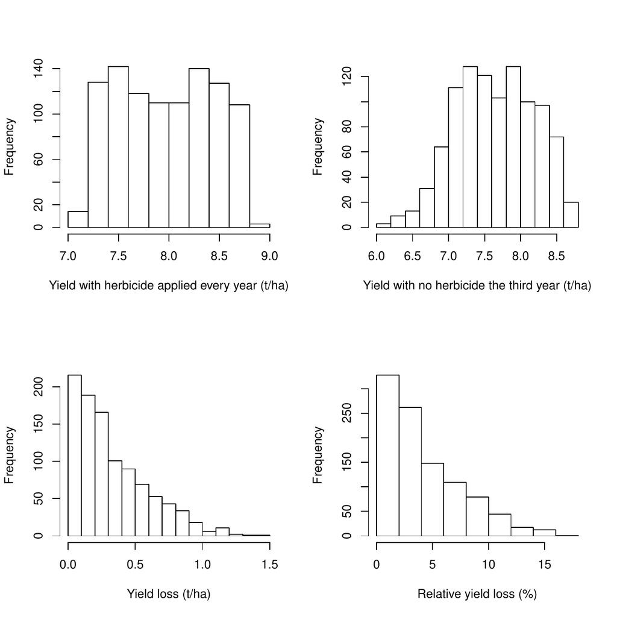

Figure 5: Histogram presenting the yields simulated with the Weed model (1000 simulations per year for 10 years). 1) Yields observed with applying herbicide every year (top-left) and without applying herbicide for the 3rd year (top-right); 2) Loss in yield due to not applying herbicide for the 3rd year expressed in $t/ha$ (bottom-left) and in percentages (bottom-right).

```r
      Y1 <- unlist(extractData(exp1, name = 'evaluate'))
      Y2 <- unlist(extractData(exp2, name = 'evaluate'))

      dev.new()
      par(mfrow = c(2,2))
      hist(Y1, main = '',
           xlab = 'Yield with  herbicide systematically applied (t/ha)')
      hist(Y2, main = '',
           xlab = 'Yield without applying herbicide for the 3rd year (t/ha)')
      hist(Y1-Y2, main = ' ', xlab = 'Loss in yield (t/ha)')
      hist(100*(Y1-Y2)/Y1, main = ' ', xlab = 'Relative loss in yield  (%)')

      summary(Y1-Y2)
```

The results are illustrated in Figure 5. It shows that the average loss is $0.33 \, t/ha$, the median loss is $0.25\, t/ha$, and the 1st and 3rd quartiles of the distribution are equal to $0.12$ and $0.48 \, t/ha$ respectively. The uncertainty analysis shows that the yield loss due to non-application of the weeding treatment has a one-in-two chance of exceeding $0.25 \, t/ha$, and has a one-in-four chance of being less than $0.12 \, t/ha$ and a one-in-four chance of exceeding $0.48 \, t/ha$. We can claim that the loss in yield is moderate, even taking into account the uncertainties of the *factors*.

## Sensitivity analysis

The uncertainty analysis described above allows the estimation of the uncertainties about the yield losses, but it gives no information about where the uncertainties come from and which *factors* have the most important impact on them. In this section, we will discuss how to use the *mtk* package to calculate the sensitivity indices for the *factors* and how to identify the most influential *factors* according to their sensitivity. Two methods will be presented: Morris (Saltelli et al. 2005) and PLMM [Polynomial Linear metamodel; Faivre (2013)]. These examples demonstrate how easy it is to use the *mtk* package to compare very different methods.

The R code below shows the sensitivity analysis with the Morris method. We can note the efficiency and effortlessness of the *mtk* package to fulfill such a procedure: We are neither concerned about where the methods are implemented (locally or remotely) nor worried about how data are organized within the processes.

```r
# Specify the processes and form the workflows:
      morris.sampler <- mtkMorrisDesigner(listParameters = list(r = 500, type = 'oat',
                           levels = 4 , grid.jump = 2, scale = TRUE))

      weed.treated <- mtkWeedEvaluator(listParameters = list(decision = 1,
                           outvar = 3))
      weed.no.treated <- mtkWeedEvaluator(listParameters = list(decision = 2,
                           outvar = 3))

      morris.analyser <- mtkMorrisAnalyser()

      exp.treated <- mtkExpWorkflow(expFactors = weedFactors,
                       processesVector = c(design = morris.sampler,
                         evaluate = weed.treated, analyze = morris.analyser))

      exp.no.treated <- mtkExpWorkflow(expFactors = weedFactors,
                         processesVector = c(design = morris.sampler,
                           evaluate = weed.no.treated, analyze = morris.analyser))
# Run the workflows:
      set.seed(2)
      run(exp.treated)
      set.seed(2)
      run(exp.no.treated)
# Report the results:
      plot(getProcess(exp.treated, name = 'analyze'))
             title("With herbicide every year")
      plot(getProcess(exp.no.treated, name = 'analyze'))
             title("With no herbicide the 3rd year")
```

Note that we make use one more time of the class ‘`mtkWeedEvaluator`’ to manage the model simulation, and that only the yields of the third year ($outvar=3$) are explored.

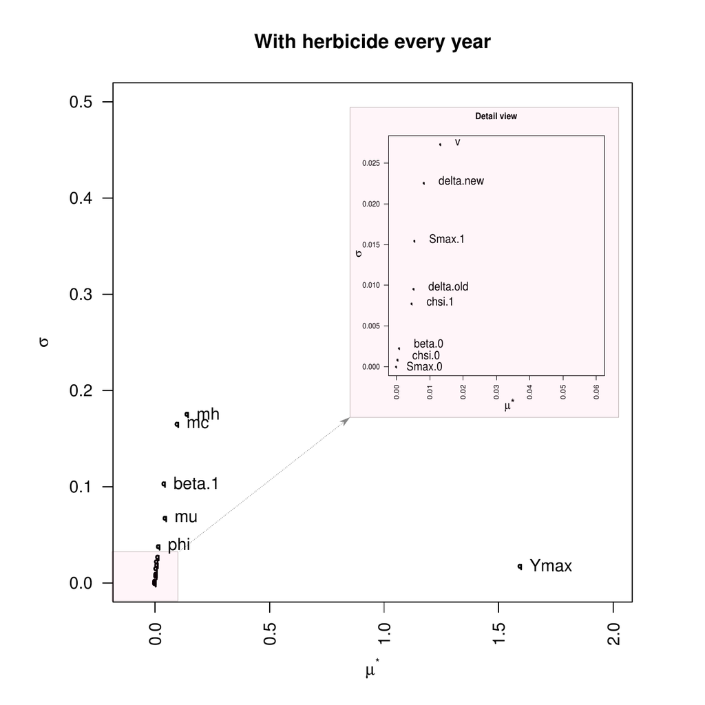

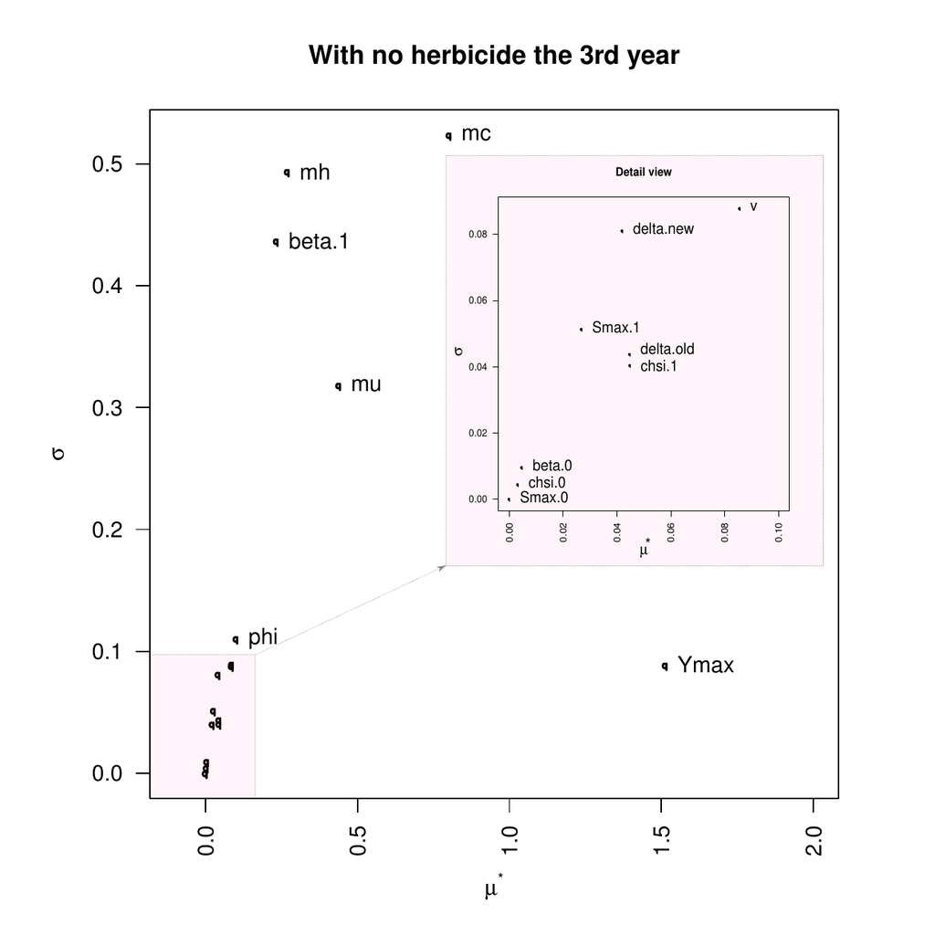

Figure 6: Sensitivity analysis results shown in graphical form for the outputs *Y* with respect to the $16$ parameters with uncertainty, calculated with the Morris method for the Weed models: 1) with herbicide applied every year (top) and 2) without applying herbicide for the 3rd year (bottom). In the Morris method, the index *μ** (on the *x*-axis) is used to detect input factors with an important overall influence on the output, and the index *σ* (on the *y*-axis) is used to detect factors involved in interaction with other factors or whose effect is non-linear.

Figure 6 shows the results of the sensitivity analysis obtained with the Morris method for the two scenarios of agricultural practices. Remember that in the method Morris, the index $\mu^*$ is used to detect the factors with important overall influence on the output and the index $\sigma$ is used to detect the factors involved in interaction with other factors or whose effect is non-linear.

We note that most factors have sensitivity indices $\mu^*$ and $\sigma$ close to 0 either with or without weeding treatment. This shows that such factors have little effect on the yield performance.

On the contrary, when weeding is applied, the factor $Ymax$ (the maximum yield potentially obtained with the underlying soil and the underlying cultivated wheat variety) has a sensitivity index $\mu^*$ larger than 1. This means that the factor $Ymax$ has significant influence on the yield performance and that the main part of the variability of the yield performance might be explained by the uncertainties contained in the factor $Ymax$. Furthermore, some factors exhibit $\sigma$ values slightly different from 0 meaning that their effect may be non-linear or interacting with others factors but with low consequences on the output.

Such a conclusion seems natural and easy to understand. In fact, when weeding treatment is applied, almost all foxtail is eliminated; their influences are wiped out and only the potential yield parameter $Ymax$ becomes decisive for the yield performance.

On the other hand, when no weeding is applied the 3rd year, the index $\mu^*$ associated with the factor $Ymax$ is not the only one to move away from 0, but also the factors $mc$, $mu$, $mh$, and $beta.1$. Meanwhile, the indices $\sigma$ associated with the factors $mc$, $mu$, and $beta.1$ are all increased significantly. This means that when no weeding is applied, $Ymax$ is no longer the only factor having significant impacts on the yield and the factors $mc$, $mu$ and $beta.1$ also imply effects on the yield performance either in a non-linear way or in interaction with other factors.

To assess the relevance of the results, we have analyzed the same models with other methods. The methods RandLHS (Latin Hypercube Sampling; Carnell (2012)) and PLMM are used respectively for the experimental design and the sensitivity analysis. The code below demonstrates the procedure. Note that we reuse the two simulators of the Weed models `weed.treated` and `weed.no.treated` previously defined.

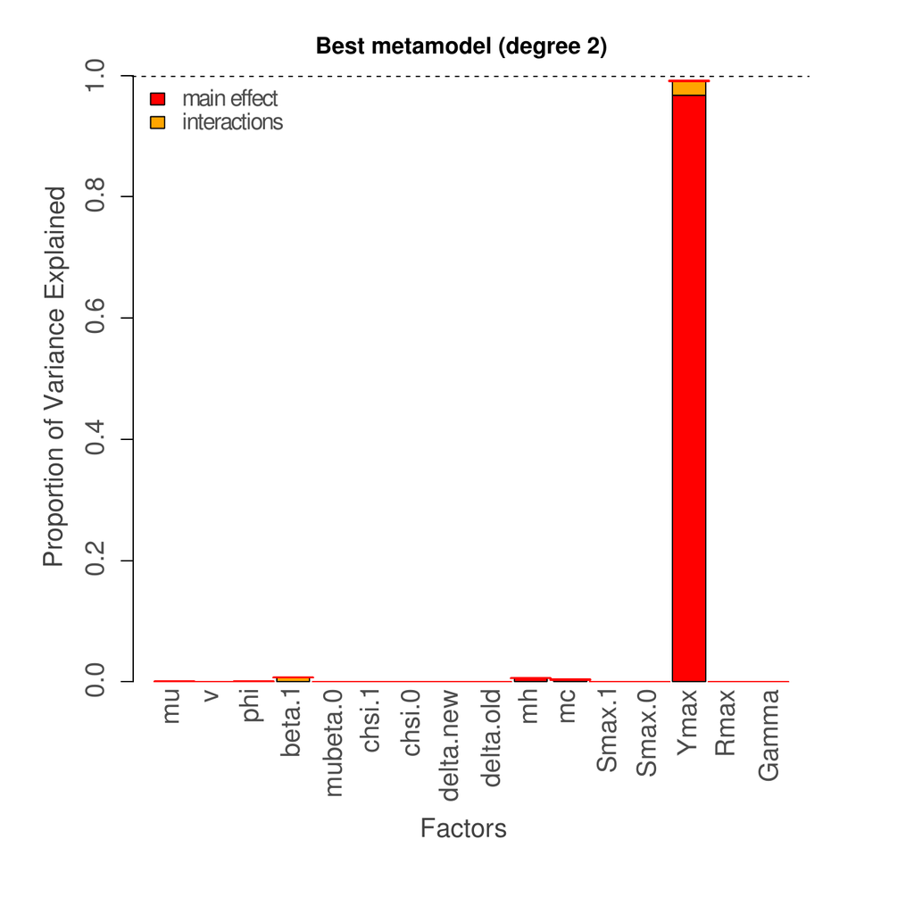

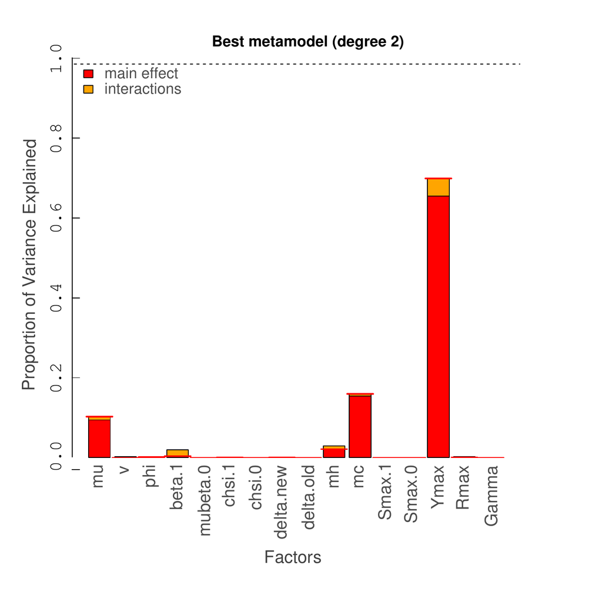

Figure 7: Sensitivity indices of the output *Y* with respect to the $16$ parameters with uncertainty, calculated by the PLMM method with a polynomial metamodel of degree $2$ for the Weed models: 1) with herbicide applied every year (left) and 2) without applying herbicide for the 3rd year (right). The *y*-axis represents the *R*<sup>2</sup> value corresponding to the fraction of the total variance of the output explained by the *factors*, and the dashed line shows the fraction of the total variance of the output explained by the metamodel.

```r
# Specify the processes and form the workflows:
      lhs.sampler <- mtkRandLHSDesigner(listParameters = list(size = 1000))
      plmm.analyser <-  mtkPLMMAnalyser(listParameters = list(degree.pol = 2))

      exp.plmm.treated <- mtkExpWorkflow(expFactors = weedFactors,
                            processesVector = c(design = lhs.sampler,
                              evaluate = weed.treated, analyze = plmm.analyser))

      exp.plmm.no.treated <- mtkExpWorkflow(expFactors = weedFactors,
                               processesVector = c(design = lhs.sampler,
                                  evaluate = weed.no.treated, analyze = plmm.analyser))
# Run the workflows:
      set.seed(2)
      run(exp.plmm.treated)
      set.seed(2)
      run(exp.plmm.no.treated)

# Report the results of the workflows:
      plot(exp.plmm.treated, legend.loc = 'topleft')
      plot(exp.plmm.no.treated, legend.loc = 'topleft')
```

Figure 7 shows the results of the sensitivity analysis obtained for the PLMM method with a polynomial metamodel of degree 2. The results uphold the conclusions obtained with the Morris method. The analyses were performed first with a regression modeling of the output on all the cross products of polynomials of factors with degree 2, and then extended by proceeding to a stepwise selection of explanatory variables. Figure 7 highlights that most of the main effects of the factors $mc$, $mu$, $mh$ and $Ymax$ are linear or polynomial and that interactions between factors are mainly between $Ymax$ and $beta.1$. We can also notice that the $R^2$, the percentage of variance explained by our metamodel, is close to 1 (zone marked with a dashed line).

# Conclusions and perspectives

There is a rapidly growing trend to utilize uncertainty and sensitivity analyses for quantifying the uncertainties contained in a model and further assessing their impacts on the behaviors of the model. Numerous methods and theories emanating from different fields have been put forward, but the issue related to software development is still lagging behind. The tools proposed are usually bespoke, context-specific and self-contained, and suffer from lack of generality and extensibility. Herein, we have developed a general-purpose framework to compile the available methods into a unique software platform which is able to provide the practitioners from different disciplines with a systematic and easy way to compare and find the best method for uncertainty discovery and sensitivity analysis.

The *mtk* package should be the first generic R platform available for uncertainty and sensitivity analyses, which allows us to collect all the methods actually available into a unique system, and present them according to the same semantics and with the same syntax. This makes the methods easy to use and their comparison effective since methods can be run with exactly the same data and in the same environment.

Building on an object-oriented framework and exploring the XML standards, the *mtk* package places its focus on the interoperability, and provides facilities for interplaying with other applications and sharing data and knowledge in a seamless way.

It is fully open-source and easy to extend. It allows users to add their own methods and models to the package easily. The power of a workflow-based approach allows researchers to organize their computing effectively and to extend the investigation in a quick manner. By decomposing the workflow into generic and elementary tasks, complex processing can be set up by combining the elementary tasks and be managed easily with the package. Moreover, the Web-based technologies and computing implemented in the package make its extension even more flexible since users have access to different ways to realize the extension: using the inheritance mechanism provided with the object-oriented framework, directly integrating native R functions, building the extension as an independent application, etc. Note also that the *mtk* package always presents the methods and models in the same way, wherever they are implemented (locally or remotely) and no matter how they are implemented (as an internal element of the package or an independent external application, etc. ).

In spite of the advanced features, the *mtk* package is still work in progress. Future plans include implementing support for High Performance Computing to improve the efficiency for time-consuming processes (Leclaire and Reuillon 2014). Further, a new version of the serialization function is also planned so that external platforms can easily integrate the *mtk* package as an internal component. Actually, state and data of the workflow managed by the package *mtk* can be exported into XML files, and used by external applications or platforms. Fine-tuning with real world examples is necessary so that an external application can use such information to wrap the *mtk* package as its internal component. When it comes to the issue of efficient large data management, we are studying the possibility to use the package [*ff*](https://CRAN.R-project.org/package=ff) for memory-efficient storage (Adler et al. 2014).

# Acknowledgement

This research was partially supported by the French methodology research network for numerical experiments (MEXICO) (http://reseau-mexico.fr). We thank all the members of this partnership, who provided insight and expertise that greatly assisted the research.

Adams, B. M., L. E. Bauman, W. J. Bohnhoff, K. R. Dalbey, J. P. Eddy, M. S. Ebeida, M. S. Eldred, et al. 2013. “Dakota: A Multilevel Parallel Object-Oriented Framework for Design Optimization, Parameter Estimation, Uncertainty Quantification, and Sensitivity Analysis. Version 5.4 User’s Manual.” Technical Report, Sandia National Labs., Albuquerque, NM and Livermore, CA.

Adler, Daniel, Christian Gläser, Oleg Nenadic, Jens Oehlschlägel, and Walter Zucchini. 2014. *Ff: Memory-Efficient Storage of Large Data on Disk and Fast Access Functions*. https://CRAN.R-project.org/package=ff.

Alden, Kieran, Mark Read, Paul Andrews, Jon Timmis, Henrique Veiga-Fernandes, and Mark Coles. 2015. *Spartan: Simulation Parameter Analysis r Toolkit ApplicatioN*. https://CRAN.R-project.org/package=spartan.

Alden, Mark AND Timmis, Kieran AND Read. 2013. “Spartan: A Comprehensive Tool for Understanding Uncertainty in Simulations of Biological Systems.” *PLoS Computational Biology* 9 (2).

Baudin, M., A. Dutfoy, B. Iooss, and A.-L. Popelin. 2015. “Open TURNS: An industrial software for uncertainty quantification in simulation.” *ArXiv e-Prints*. https://arxiv.org/abs/1501.05242.

Brock, J. T., C. L. Caupp, and H. M. Runke. 1992. *Evaluation of Water Quality Using DSSAM III Under Various Conditions of Nutrient Loadings from Municipal Wastewater and Agricultural Sources, Truckee River, Nevada: Comparison of Simulated Water Quality Conditions with Truckee River Water Quality Standards from McCarran to Pyramid Lake. Executive Summary*. Bureau of Water Quality Planning, Nevada Division of Environmental Protection.

Cariboni, J., D. Gatelli, R. Liska, and A. Saltelli. 2007. “The Role of Sensitivity Analysis in Ecological Modelling.” *Ecological Modelling* 203 (1–-2): 167–82.

Carnell, Rob. 2012. *Lhs: Latin Hypercube Samples*. https://CRAN.R-project.org/package=lhs.

Chambers, John M. 2008. *Software for Data Analysis: Programming with r*. Springer.

———. 2014. “Object-Oriented Programming, Functional Programming and R.” *Statistical Science* 29 (2): 167–80.

Ciuffo, B., A. Miola, V. Punzo, and S. Sala. 2012. *Dealing with Uncertainty in Sustainability Assessment: Report on the Application of Different Sensitivity Analysis Techniques to Fieldspecific Simulation Models*. Publications Office, Joint Research Centre. Institute for Environment; Sustainability, Luxembourg.

Dupuy, Delphine, Céline Helbert, and Jessica Franco. 2015. “DiceDesign and DiceEval: Two R Packages for Design and Analysis of Computer Experiments.” *Journal of Statistical Software* 65 (11): 1–38. http://www.jstatsoft.org/v65/i11/.

Faivre, R. 2013. *Exploration par construction de métamodèles*. Savoir Faire. Versailles, France: Quae.

Faivre, R., D. Makowski, J. Wang, H. Richard, and H. Monod. 2013. *Exploration numérique d’un modèle agronomique avec le package “mtk”*. Savoir Faire. Versailles, France: Quae.

Fowler, Martin. 2003. *UML Distilled: A Brief Guide to the Standard Object Modeling Language*. 3rd ed. Boston, MA, USA: Addison-Wesley Longman Publishing Co., Inc.

Helton, J. C., J. D. Johnson, C. J. Sallaberry, and C. B. Storlie. 2006. “Survey of Sampling-Based Methods for Uncertainty and Sensitivity Analysis.” *Reliability Engineering and System Safety* 91 (10–-11): 1175–1209.

Hornberger, G. M., and R. C. Spear. 1981. “An Approach to the Preliminary Analysis of Environmental Systems.” *Journal of Environmental Management* 12: 7–18.

Ishigami, T., and T. Homma. 1990. “An importance quantification technique in uncertainty analysis for computer models.” In *International Symposium on Uncertainity Modelling and Analysis (ISUMA’90)*. Dec. 3–6, University of Maryland.

Joint Research Centre. 2006. “SimLab.” Software. http://simlab.jrc.cec.eu.int.

Lamboni, Matieyendou, Hervé Monod, and Caroline Bidot. 2015. *Multisensi: Multivariate Sensitivity Analysis*. https://CRAN.R-project.org/package=multisensi.

Leclaire, Mathieu, and Romain Reuillon. 2014. “OpenMole: OPEN MOdeL Experiment.” Open-Source Software; Institute of Complex System, Paris. http://www.openmole.org.

Lynch, Peter. 2008. “The Origins of Computer Weather Prediction and Climate Modeling.” *Journal of Computational Physics* 227 (7): 3431–44.

Marino, Simeone, Ian B. Hogue, Christian J. Ray, and Denise E. Kirschner. 2008. “A Methodology for Performing Global Uncertainty and Sensitivity Analysis in Systems Biology.” *Journal of Theoretical Biology* 254 (1): 178–96.

Monod, Hervé, Annie Bouvier, and André Kobilinsky. 2015. *Planor: Generation of Regular Factorial Designs*. https://CRAN.R-project.org/package=planor.

Munier-Jolain, N. M., B. Chauvel, and J. Gasquez. 2002. “Long-Term Modelling of Weed Control Strategies: Analysis of Threshold-Based Options for Weed Species with Contrasted Competitive Abilities.” *Weed Research* 42: 107–22.

Papaix, Julien, Suzanne Touzeau, Hervé Monod, and Christian Lannou. 2014. “Can Epidemic Control Be Achieved by Altering Landscape Connectivity in Agricultural Systems?” *Ecological Modelling* 284: 35–47.

Pronzato, Luc, and WernerG. Müller. 2012. “Design of Computer Experiments: Space Filling and Beyond.” *Statistics and Computing* 22 (3): 681–701.

Pujol, Gilles, Bertrand Iooss, and Alexandre Janon. 2014. *The Sensitivity Package*. https://CRAN.R-project.org/package=sensitivity.

Read, Mark, Paul S. Andrews, Jon Timmis, and Vipin Kumar. 2012. “Techniques for Grounding Agent-Based Simulations in the Real Domain: A Case Study in Experimental Autoimmune Encephalomyelitis.” *Mathematical and Computer Modelling of Dynamical Systems* 18 (1): 67–86.

Richard, H., H. Monod, J. Wang, J. Couteau, N. Dumoulin, B. Poussin, J. C. Soulié, and E. Ramat. 2013. *La boîte à outils Mexico: un environnement générique pour piloter l’exploration numérique de modèles*. Savoir Faire. Versailles, France: Quae.

Richet, Y. et al. 2009. “The Promethee project: A software environment for performing parametric computer simulations in dependability engineering.” http://promethee.irsn.org.

Richet, Y., D. Ginsbourger, O. Roustant, and Y. Deville. 2010. “A Grid Computing Environment for Design and Analysis of Computer Experiments.” In *The r User Conference*. July 20–23 2010, Gaithersburg, Maryland, USA.

Risbey, James S., Stephan Lewandowsky, Clothilde Langlais, Didier P. Monselesan, Terence J. O’Kane, and Naomi Oreskes. 2014. “Well-estimated global surface warming in climate projections selected for ENSO phase.” *Nature Climate Change* 4 (9): 835–40.

Rocquigny, Etienne de, Nicolas Devictor, and Stefano Tarantola. 2008. *Uncertainty in Industrial Practice: A Guide to Quantitative Uncertainty Management*. John Wiley & Sons.

Salinger, A. G., R. P. Pawlowski, J. N. Shadid, and B. van Bloemen Waanders. 2004. “Computational Analysis and Optimization of a Chemical Vapor Deposition Reactor with Large-Scale Computing.” *Industrial and Engineering Chemistry Research* 43 (16): 4612–23.

Saltelli, A., K. Chan, and E. M. Scott. 2000. *Sensitivity Analysis*. Wiley.

Saltelli, A., M. Ratto, S. Tarantola, and Campolongo F. 2005. *Sensitivity Analysis in Practice: A Guide to Assessing Scientific Models*. John Wiley; Sons.